# Part II - Ford GoBike System (A Case of San Francisco Bay Area)

## by (Derrick Narkah)

## Investigation Overview

In this investigation, I wanted to find ways of improving the GoBike System by focusing more on the Bike Stations and other factors associated with the users of the system.

## Dataset Overview

The Ford GoBike System Data is data collected on 183413 individual rides made in a bike-sharing program in the San Francisco Bay Area covering the period of February 2019.

## Top 7 and Last 7 Stations with the MOST and LEAST Number of Rides and their Location.

There are 328 Stations represented in the data set. Each ride starts from one station and ends in another. Since each start station also featured in the end station, I had to group the start station id's and count the number of times each one station appeared in the dataset programmatically. The then found the 75% percentile and filtered all stations whose number of rides within the 75% percentile. This was plotted in descending order and the top 7 could be easily seen The same procedure is followed to find the Bottom 7 with the least Number of rides. The coordinates of the 14 stations found (Top 7 plus Bottom 7) are then plotted on an actual map of the San Francisco Bay.

INSIGHT: The Plot shows the Top 7 Stations with the MOST number of rides ar located closer to the bay area than the Bottom 7 Stations with the LEAST number of rides which are relatively farther away

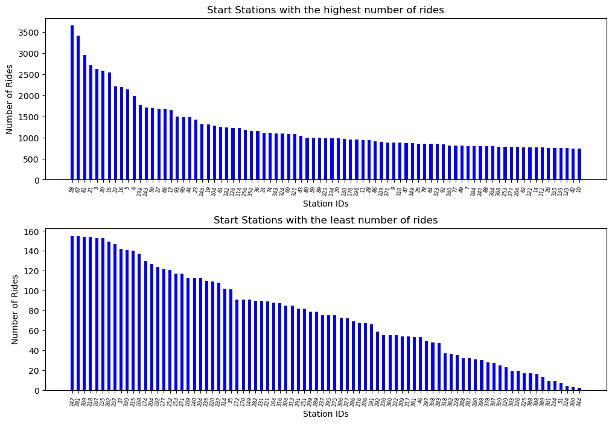

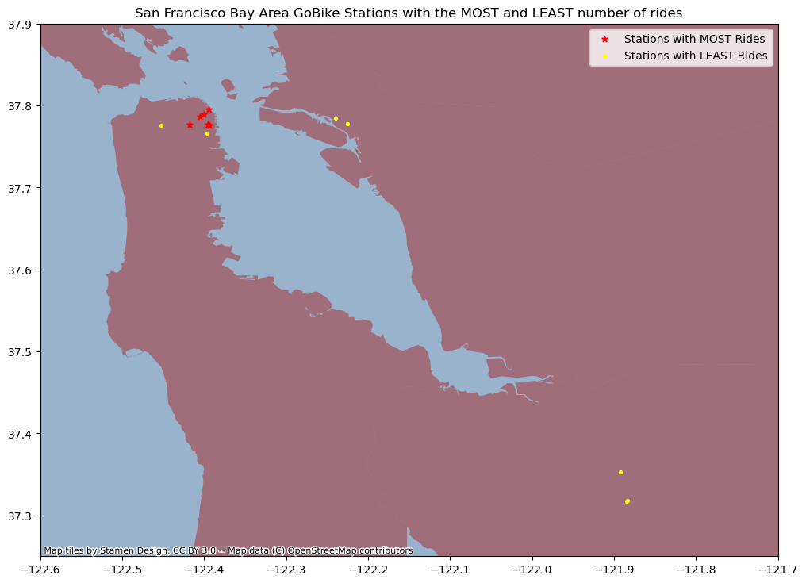

## Categorical Values associated with Top 7 and Bottom 7 Stations

The 3 Categorical columns are User Type (Subscriber or Customer), Member Gender (Male, Female, Other), Bike Share For All (Yes, No). I intend to see how these are distributed among the top 7 and Bottom 7 Stations. This will be plotted in subplots for easy comparison

INSIGHT: For the Top 7 Stations, the charts are very skewed. Males dominated the number of rides as well as those without the Bike Share For All discount But for the Bottom 7 Stations, these charts varied slightly, the Females in some stations were almost equal to the Males. One other station had more Bike Share for All discount users.

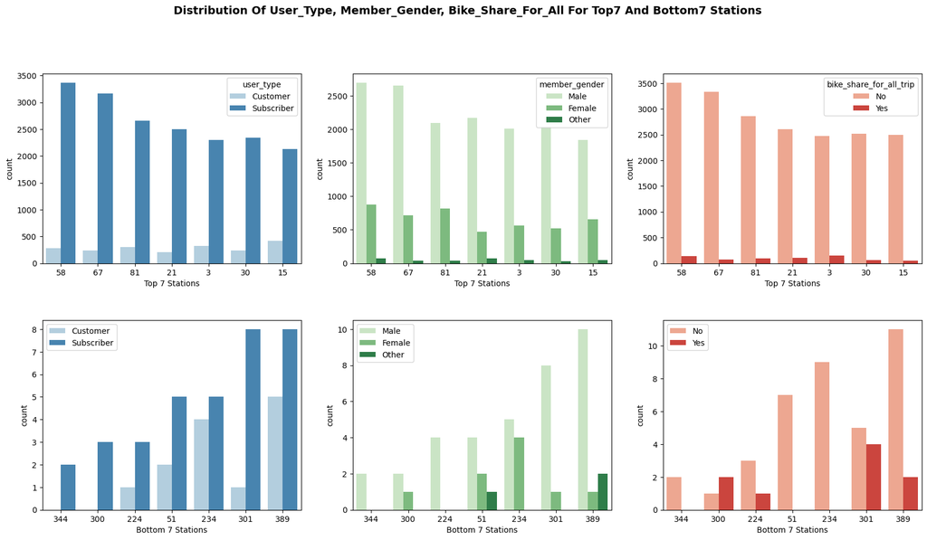